# Titanic_exploration

### This is an exploration of data on the Titanic

The data set included information on 891 of the 2224 passengers aboard the Titanic. This is an iPython Notebook file which allows me to display blocks of code together with html text explaining my code. Each of the following blocks contain the input of my code and the output it produced.

I used the PANDAS library in Python to read the csv file into a dataframe which can viewed in the output below. The dataframe creates a table for the data. I named my dataframe 'titanic_df' and used the head() function to print only the first 5 rows of the table to make sure it was made correctly.

Once the table printed correctly I began asking questions about the data.

```python
import matplotlib.pyplot as plt
import numpy as np
import pandas as pd
import seaborn as sns

filename = 'https://d17h27t6h515a5.cloudfront.net/topher/2016/September/57e9a84c_titanic-data/titanic-data.csv'
titanic_df = pd.read_csv(filename)

## Print first 5 lines of dataframe
titanic_df.head()
```

|  | PassengerId | Survived | Pclass | Name | Sex | Age | SibSp | Parch | Ticket | Fare | Cabin | Embarked |
| --- | --- | --- | --- | --- | --- | --- | --- | --- | --- | --- | --- | --- |
| 0 | 1 | 0 | 3 | Braund, Mr. Owen Harris | male | 22 | 1 | 0 | A/5 21171 | 7.2500 | NaN | S |
| 1 | 2 | 1 | 1 | Cumings, Mrs. John Bradley (Florence Briggs Th... | female | 38 | 1 | 0 | PC 17599 | 71.2833 | C85 | C |
| 2 | 3 | 1 | 3 | Heikkinen, Miss. Laina | female | 26 | 0 | 0 | STON/O2. 3101282 | 7.9250 | NaN | S |
| 3 | 4 | 1 | 1 | Futrelle, Mrs. Jacques Heath (Lily May Peel) | female | 35 | 1 | 0 | 113803 | 53.1000 | C123 | S |
| 4 | 5 | 0 | 3 | Allen, Mr. William Henry | male | 35 | 0 | 0 | 373450 | 8.0500 | NaN | S |

### What was the most common age and sex of a survivor?

I split the original dataframe 'titanic_df' into separate dataframes for men and women. I named them 'mens_df' and 'womens_df'.

```python
%pylab inline
import seaborn as sns

## Split data into male and female
## Create mens_df and womens_df
mens_df = titanic_df[(titanic_df['Sex'] == 'male')]
womens_df = titanic_df[(titanic_df['Sex'] == 'female')]
```

Then I found the age that had the most survivors in male dataframe and the age that had the most survivors in the female dataframe. I used an if statement to show the combination of age and sex had the highest number of survivors. 24 year old females had the highest number of survivals.

```python
male_age_mode = mens_df.groupby('Age').sum()['Survived'].idxmax()
sum_male_age = mens_df.groupby('Age').sum()['Survived'].max()
female_age_mode = womens_df.groupby('Age').sum()['Survived'].idxmax()
sum_female_age = womens_df.groupby('Age').sum()['Survived'].max()

if sum_male_age > sum_female_age:
    print '{} year old males had the most survivals.' .format(male_age_mode)
else:
    print '{} year old females had the most survivals.' .format(female_age_mode)
```

```
24.0 year old females had the most survivals.
```

### What was the correlation between sex and survival of a passenger?

```python
## Correlation function
def correlation(x, y):
    standardized_x = (x - x.mean())/(x.std(ddof = 0))
    standardized_y = (y - y.mean())/(y.std(ddof = 0))
    product = standardized_x * standardized_y
    correlation = product.mean()
    return correlation

## Replace male with 1 and female with 0
sex_num = titanic_df.replace(['male', 'female'], [1, 2])
print 'correlation between sex and survival:', correlation(sex_num['Sex'], sex_num['Survived'])
```

```
correlation between sex and survival: 0.543351380658
```

I wrote a function to calculate the correlation between two variables and explored the correlation between a passenger's sex and their survival. Values of correlation range from -1 to 1. A value of 1 means that a passengers who were a particular sex also had a high number of survivals. This is a strong positive correlation. A value of -1 means that passengers who were a particular sex also had a low number of survivals. This is a strong negative correlation.

The correlation between a passenger's sex and their survival was 0.54. This means that there was a positive correlation between these variables and the strength of the correlation was almost exactly in the middle between strong and weak. Although a passenger's sex did not determine their survival, there was a noticable difference between male and female survivals.

### What age group had the most survivors for each sex?

There were a lot of missing values in the age column of the male and female dataframes. I printed the 5th and 6th rows of the dataframe as an example. These values appeared in the table as "NaN" which is short for "not a number."

```python
titanic_df.loc[5:6]
```

|  | PassengerId | Survived | Pclass | Name | Sex | Age | SibSp | Parch | Ticket | Fare | Cabin | Embarked |
| --- | --- | --- | --- | --- | --- | --- | --- | --- | --- | --- | --- | --- |
| 5 | 6 | 0 | 3 | Moran, Mr. James | male | NaN | 0 | 0 | 330877 | 8.4583 | NaN | Q |
| 6 | 7 | 0 | 1 | McCarthy, Mr. Timothy J | male | 54 | 0 | 0 | 17463 | 51.8625 | E46 | S |

I used the pd.isnull() function to only show me the values in the age column that are not equal to a null value such as NaN. The pd.cut() function was used to split the ages into bins for each age group. These bins ranged from [-1, 9, 19, 29, ... 89] where each bin of the form [x, y] includes values in the interval (x,y]. For example, [-1, 9] includes the interval from 0 to 9. Then I used dataframe.groupby() to sum the survivors in each age group for men and women.

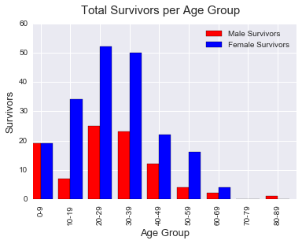

```python
## Exclude NaN values in mens_df

mens_df = mens_df[pd.isnull(mens_df['Age']) != True]
womens_df = womens_df[pd.isnull(womens_df['Age']) != True]

## Put passengers into age groups using pd.cut()
## Each bin is in the form (x,y]
## Where y is included in the interval but x is not

bins = [-1, 9, 19, 29, 39, 49, 59, 69, 79, 89]
group_names = ['0-9', '10-19', '20-29', '30-39', '40-49', '50-59', '60-69', '70-79', '80-89']
men_age_groups = pd.cut(mens_df['Age'], bins, labels=group_names)
women_age_groups = pd.cut(womens_df['Age'], bins, labels=group_names)

## I renamed the columns to get the correct legend on the graph

mens_df['Male Survivors'] = mens_df['Survived']
womens_df['Female Survivors'] = womens_df['Survived']

male_survivors_per_age_group = mens_df.groupby(men_age_groups).sum()['Male Survivors']
female_survivors_per_age_group = womens_df.groupby(women_age_groups).sum()['Female Survivors']

#male_survivors_per_age_group.describe()

fig = plt.figure() # Create matplotlib figure

width = 0.4

ax = male_survivors_per_age_group.plot(kind='bar', color='red', width=width, position=1, legend = True)
ax = female_survivors_per_age_group.plot(kind='bar', color='blue', width=width, position=0, legend = True)

fig.suptitle('Total Survivors per Age Group', fontsize = 15)

plt.xlabel('Age Group', fontsize=13)
plt.ylabel('Survivors', fontsize=13)

plt.show()
```

```python
print 'Male data: \n', male_survivors_per_age_group.describe()
print 'Female data: \n', female_survivors_per_age_group.describe()
```

```
Male data:
count     9.000000
mean     10.333333
std       9.797959
min       0.000000
25%       2.000000
50%       7.000000
75%      19.000000
max      25.000000
Name: Male Survivors, dtype: float64
Female data:
count     7.000000
mean     28.142857
std      17.948339
min       4.000000
25%      17.500000
50%      22.000000
75%      42.000000
max      52.000000
Name: Female Survivors, dtype: float64
```